# M05-1: Principles - Expanded In-depth Data Wrangling with Tidyverse in R

Author

Allen Cosme

Published

March 9, 2026

# 1 Air quality

## 1.1 Convert airquality to a tibble (air.tib), then to a data.frame (air.df)

```r
library(tidyverse)

# air qual. -> tibble
air.tib <- as_tibble(airquality)

class(air.tib)
```

```
[1] "tbl_df"     "tbl"        "data.frame"
```

```r
is_tibble(air.tib)
```

```
[1] TRUE
```

```r
# tibble -> base data. frame
air.df <- as.data.frame(air.tib)

#confirm data.frame
class(air.df)
```

```
[1] "data.frame"
```

```r
is.data.frame(air.df) # true
```

```
[1] TRUE
```

```r
is_tibble(air.tib) #false
```

```
[1] TRUE
```

## 1.2 Find Ozone when Temp == 97 (row + Ozone-only), using Base R and Tidyverse

```r
air.tib[air.tib$Temp == 97, ]
```

| Ozone | Solar.R | Wind | Temp | Month | Day |
| --- | --- | --- | --- | --- | --- |
| 76 | 203 | 9.7 | 97 | 8 | 28 |

```r
air.tib %>% filter(Temp ==97)
```

| Ozone | Solar.R | Wind | Temp | Month | Day |
| --- | --- | --- | --- | --- | --- |
| 76 | 203 | 9.7 | 97 | 8 | 28 |

```r
air.tib$Ozone[air.tib$Temp ==97]
```

```
[1] 76
```

```r
air.tib %>% filter(Temp == 97) %>% pull(Ozone)
```

```
[1] 76
```

# 2 FLight delay

## 2.1 Top 10 worst arrival delays per day → average (of those) by month

```r
library(tidyverse)
library(nycflights13)

# Top 10 worst arrival delays per (year, month, day),
# then average those delays by month (ignoring year/day)
monthly_avg_top10 <- flights %>%
  filter(!is.na(arr_delay)) %>%                 # remove NAs so "worst" is meaningful
  group_by(year, month, day) %>%
  slice_max(order_by = arr_delay, n = 10, with_ties = FALSE) %>%
  ungroup() %>%                                 # remove day-level grouping
  group_by(month) %>%
  summarise(
    avg_delay_top10 = mean(arr_delay),
    .groups = "drop"
  )
```

## 2.2 Visualization of average delays each month

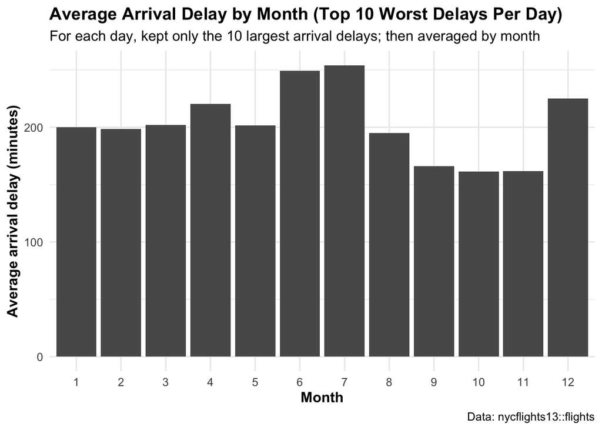

```r
library(ggplot2)

monthly_avg_top10 %>%
  ggplot(aes(x = factor(month), y = avg_delay_top10)) +
  geom_col() +
  labs(
    title = "Average Arrival Delay by Month (Top 10 Worst Delays Per Day)",
    subtitle = "For each day, kept only the 10 largest arrival delays; then averaged by month",
    x = "Month",
    y = "Average arrival delay (minutes)",
    caption = "Data: nycflights13::flights"
  ) +
  theme_minimal(base_size = 12) +
  theme(
    plot.title = element_text(face = "bold"),
    axis.title = element_text(face = "bold")
  )
```

**NoteKey Insight**

This chart reflects **extreme delay behavior** rather than typical delays: it averages only the **10 worst arrival delays per day**. Months with higher bars indicate that the *worst daily delays* tend to be especially severe in that part of the year.

In practice, this pattern often aligns with **seasonal disruption drivers** (e.g., summer storms, winter weather, and peak travel demand), which can amplify delay severity even if the *average flight* is not dramatically worse.

# 3 Religion vs. income

## 3.1 Explore relig_income (type, size, missing values, variables) + what we can tell

```r
library(tidyverse)

relig_income
```

| religion | <$10k | $10-20k | $20-30k | $30-40k | $40-50k | $50-75k | $75-100k | $100-150k | >150k | Don't know/refused |
| --- | --- | --- | --- | --- | --- | --- | --- | --- | --- | --- |
| Agnostic | 27 | 34 | 60 | 81 | 76 | 137 | 122 | 109 | 84 | 96 |
| Atheist | 12 | 27 | 37 | 52 | 35 | 70 | 73 | 59 | 74 | 76 |
| Buddhist | 27 | 21 | 30 | 34 | 33 | 58 | 62 | 39 | 53 | 54 |
| Catholic | 418 | 617 | 732 | 670 | 638 | 1116 | 949 | 792 | 633 | 1489 |
| Don’t know/refused | 15 | 14 | 15 | 11 | 10 | 35 | 21 | 17 | 18 | 116 |
| Evangelical Prot | 575 | 869 | 1064 | 982 | 881 | 1486 | 949 | 723 | 414 | 1529 |
| Hindu | 1 | 9 | 7 | 9 | 11 | 34 | 47 | 48 | 54 | 37 |
| Historically Black Prot | 228 | 244 | 236 | 238 | 197 | 223 | 131 | 81 | 78 | 339 |
| Jehovah's Witness | 20 | 27 | 24 | 24 | 21 | 30 | 15 | 11 | 6 | 37 |
| Jewish | 19 | 19 | 25 | 25 | 30 | 95 | 69 | 87 | 151 | 162 |

[output cut: 8 more lines]

```r
class(relig_income)
```

```
[1] "tbl_df"     "tbl"        "data.frame"
```

```r
dim(relig_income)
```

```
[1] 18 11
```

```r
glimpse(relig_income)
```

```
Rows: 18
Columns: 11
$ religion             <chr> "Agnostic", "Atheist", "Buddhist", "Catholic", "D…
$ `<$10k`              <dbl> 27, 12, 27, 418, 15, 575, 1, 228, 20, 19, 289, 29…
$ `$10-20k`            <dbl> 34, 27, 21, 617, 14, 869, 9, 244, 27, 19, 495, 40…
$ `$20-30k`            <dbl> 60, 37, 30, 732, 15, 1064, 7, 236, 24, 25, 619, 4…
$ `$30-40k`            <dbl> 81, 52, 34, 670, 11, 982, 9, 238, 24, 25, 655, 51…
$ `$40-50k`            <dbl> 76, 35, 33, 638, 10, 881, 11, 197, 21, 30, 651, 5…
$ `$50-75k`            <dbl> 137, 70, 58, 1116, 35, 1486, 34, 223, 30, 95, 110…
$ `$75-100k`           <dbl> 122, 73, 62, 949, 21, 949, 47, 131, 15, 69, 939, …
$ `$100-150k`          <dbl> 109, 59, 39, 792, 17, 723, 48, 81, 11, 87, 753, 4…
$ `>150k`              <dbl> 84, 74, 53, 633, 18, 414, 54, 78, 6, 151, 634, 42…
$ `Don't know/refused` <dbl> 96, 76, 54, 1489, 116, 1529, 37, 339, 37, 162, 13…
```

```r
names(relig_income)
```

```
 [1] "religion"           "<$10k"              "$10-20k"
 [4] "$20-30k"            "$30-40k"            "$40-50k"
 [7] "$50-75k"            "$75-100k"           "$100-150k"
[10] ">150k"              "Don't know/refused"
```

```r
# missing valise check (counts N/a per column)
colSums(is.na(relig_income))
```

```
          religion              <$10k            $10-20k            $20-30k
                 0                  0                  0                  0
           $30-40k            $40-50k            $50-75k           $75-100k
                 0                  0                  0                  0
         $100-150k              >150k Don't know/refused
                 0                  0                  0
```

```r
# summary for each column
summary(relig_income)
```

```
   religion             <$10k           $10-20k          $20-30k
 Length:18          Min.   :  1.00   Min.   :  2.00   Min.   :   3.0
 Class :character   1st Qu.: 12.25   1st Qu.: 14.75   1st Qu.:  17.0
 Mode  :character   Median : 20.00   Median : 27.00   Median :  33.5
                    Mean   :107.22   Mean   :154.50   Mean   : 186.5
                    3rd Qu.:170.00   3rd Qu.:193.00   3rd Qu.: 192.0
                    Max.   :575.00   Max.   :869.00   Max.   :1064.0
    $30-40k          $40-50k         $50-75k           $75-100k
 Min.   :  4.00   Min.   :  2.0   Min.   :   7.00   Min.   :  3.00
 1st Qu.: 15.75   1st Qu.: 15.0   1st Qu.:  34.25   1st Qu.: 25.25
 Median : 40.00   Median : 34.0   Median :  66.50   Median : 65.50
 Mean   :183.44   Mean   :171.4   Mean   : 288.06   Mean   :221.67
 3rd Qu.:198.75   3rd Qu.:166.8   3rd Qu.: 201.50   3rd Qu.:128.75
 Max.   :982.00   Max.   :881.0   Max.   :1486.00   Max.   :949.00
   $100-150k         >150k        Don't know/refused
 Min.   :  4.0   Min.   :  4.00   Min.   :   8.00
 1st Qu.: 22.5   1st Qu.: 23.75   1st Qu.:  41.25
 Median : 48.5   Median : 53.50   Median :  74.50
 Mean   :177.6   Mean   :144.89   Mean   : 340.06
 3rd Qu.:103.5   3rd Qu.:134.25   3rd Qu.: 294.75
 Max.   :792.0   Max.   :634.00   Max.   :1529.00
```

## 3.2 help for relig_income

```r
help("relig_income") # or ?relig_income
```

## 3.3 Does the current data support “income bracket frequency by religion”? Is it tidy? How reshape?

**Does it support the goal?**

Yes, it contains the information, but it’s not in tidy (long) form for easy plotting.

**Why not tidy right now?**

- Income brackets are stored as column names, not as values in a single income variable.
- That violates tidy-data rules: one variable per column.
- Here, “income bracket” is a variable spread across many columns.

**How should it be reshaped?**

Use pivot_longer() so you end up with: - religion (category) - income (income bracket) - count (frequency)

That format makes grouped plots (like bar charts) straightforward.

## 3.4 reshape data and plotting income distribution be religion

```r
library(tidyverse)

relig_income_longer <- relig_income %>%
  pivot_longer(
    cols = -religion,
    names_to = "income",
    values_to = "count"
  ) %>%
  filter(income != "Don't know/refused")
```

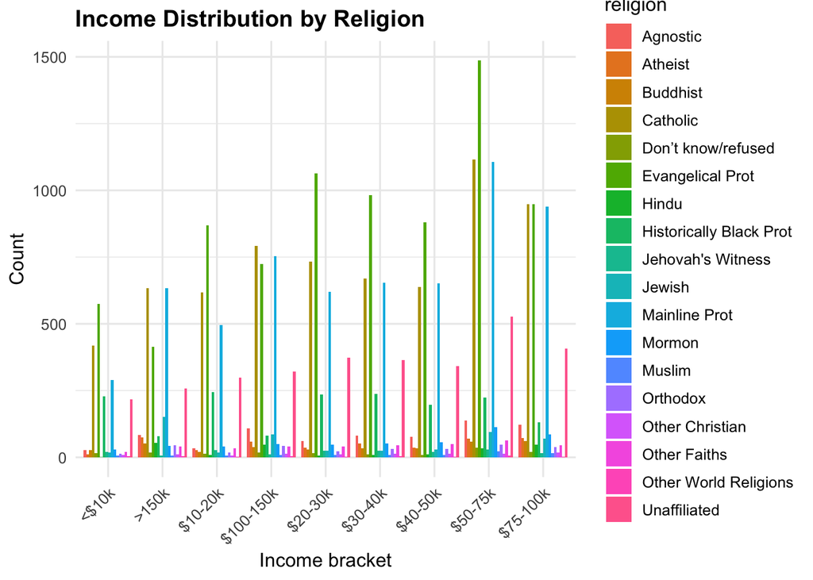

```r
relig_income_longer %>%
  ggplot(aes(x = income, y = count, fill = religion)) +
  geom_col(position = "dodge") +
  labs(
    title = "Income Distribution by Religion",
    x = "Income bracket",
    y = "Count"
  ) +
  theme_minimal(base_size = 12) +
  theme(
    plot.title = element_text(face = "bold"),
    axis.text.x = element_text(angle = 45, hjust = 1)
  )
```

# 4 Income distribution by religion

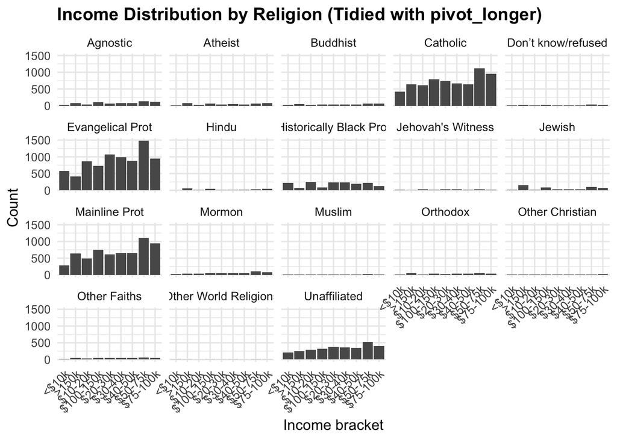

```r
library(tidyverse)

relig_income %>%
  pivot_longer(
    cols = -religion,
    names_to = "income",
    values_to = "count"
  ) %>%
  filter(income != "Don't know/refused") %>%
  ggplot(aes(x = income, y = count)) +
  geom_col() +
  facet_wrap(~ religion) +
  labs(
    title = "Income Distribution by Religion (Tidied with pivot_longer)",
    x = "Income bracket",
    y = "Count"
  ) +
  theme_minimal(base_size = 12) +
  theme(
    plot.title = element_text(face = "bold"),
    axis.text.x = element_text(angle = 45, hjust = 1)
  )
```

# 5 Rents relationship to income in the US

## 5.1 Explore us_rent_income

```r
library(tidyverse)

us_rent_income
```

| GEOID | NAME | variable | estimate | moe |
| --- | --- | --- | --- | --- |
| 01 | Alabama | income | 24476 | 136 |
| 01 | Alabama | rent | 747 | 3 |
| 02 | Alaska | income | 32940 | 508 |
| 02 | Alaska | rent | 1200 | 13 |
| 04 | Arizona | income | 27517 | 148 |
| 04 | Arizona | rent | 972 | 4 |
| 05 | Arkansas | income | 23789 | 165 |
| 05 | Arkansas | rent | 709 | 5 |
| 06 | California | income | 29454 | 109 |
| 06 | California | rent | 1358 | 3 |

[output cut: 94 more lines]

```r
class(us_rent_income)
```

```
[1] "tbl_df"     "tbl"        "data.frame"
```

```r
dim(us_rent_income)
```

```
[1] 104   5
```

```r
glimpse(us_rent_income)
```

```
Rows: 104
Columns: 5
$ GEOID    <chr> "01", "01", "02", "02", "04", "04", "05", "05", "06", "06", "…
$ NAME     <chr> "Alabama", "Alabama", "Alaska", "Alaska", "Arizona", "Arizona…
$ variable <chr> "income", "rent", "income", "rent", "income", "rent", "income…
$ estimate <dbl> 24476, 747, 32940, 1200, 27517, 972, 23789, 709, 29454, 1358,…
$ moe      <dbl> 136, 3, 508, 13, 148, 4, 165, 5, 109, 3, 109, 5, 195, 5, 247,…
```

```r
names(us_rent_income)
```

```
[1] "GEOID"    "NAME"     "variable" "estimate" "moe"
```

```r
colSums(is.na(us_rent_income))
```

```
   GEOID     NAME variable estimate      moe
       0        0        0        1        1
```

```r
summary(us_rent_income)
```

```
    GEOID               NAME             variable            estimate
 Length:104         Length:104         Length:104         Min.   :  464.0
 Class :character   Class :character   Class :character   1st Qu.:  864.5
 Mode  :character   Mode  :character   Mode  :character   Median : 1507.0
                                                          Mean   :14923.1
                                                          3rd Qu.:28872.0
                                                          Max.   :43198.0
                                                          NA's   :1
      moe
 Min.   :  2.0
 1st Qu.:  4.5
 Median : 18.0
 Mean   : 95.5
 3rd Qu.:153.5
 Max.   :681.0
 NA's   :1
```

What does the data set tell us?

- it’s a tibble
- there are 5 total variables GEOID, Name, variable, Estimate, moe.
- each state is combined with a variable like income or rent
- Estimate is estimated value and moe is margin of error
- missing values may be present

## 5.2 help/variable meanings

```r
help("us_rent_income")
```

## 5.3

**goal**: plot a relationship between income and rent across different states

**does the current table directly support our goal**

No, since income and rent are in different rows. For a scatter plot, you want a one row per state that has both rent and income

**how can we reshape** - use the pivot_wider function in order to make the column names: - estimate_income, estimate_rent - moe_income, moe_rent

doing this makes it easier to plot and analyze income against rent

## 5.4 Reshape to wide + plot income vs rent

```r
library(tidyverse)

us_rent_income_wider <- us_rent_income %>%
  pivot_wider(
    names_from  = variable,
    values_from = c(estimate, moe),
    names_sep   = "_"
  )
```

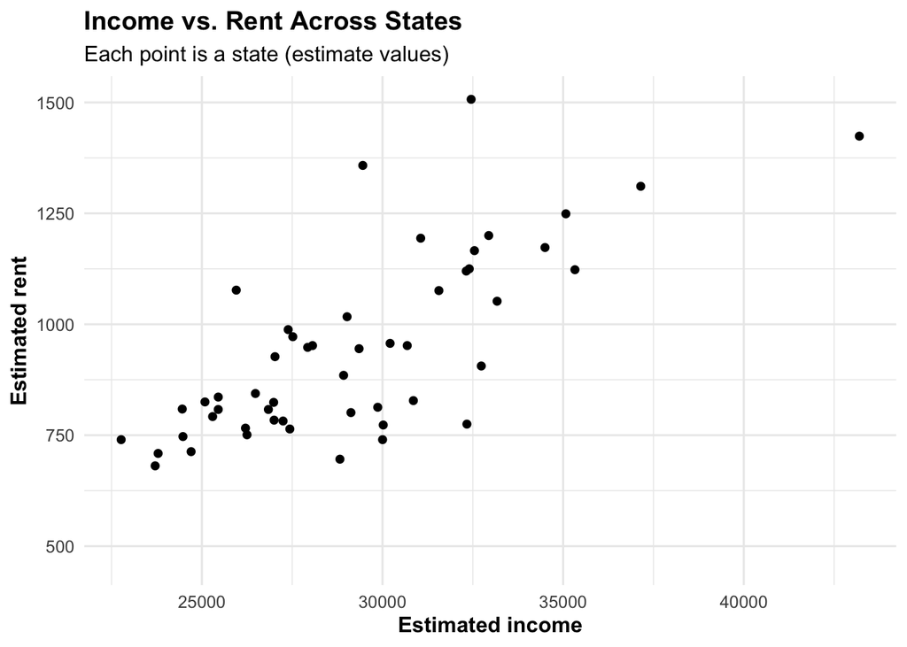

```r
us_rent_income_wider %>%
  ggplot(aes(x = estimate_income, y = estimate_rent)) +
  geom_point() +
  labs(
    title = "Income vs. Rent Across States",
    subtitle = "Each point is a state (estimate values)",
    x = "Estimated income",
    y = "Estimated rent"
  ) +
  theme_minimal(base_size = 12) +
  theme(
    plot.title = element_text(face = "bold"),
    axis.title = element_text(face = "bold")
  )
```

## 5.5 data reshape to wide + plot income v. rent

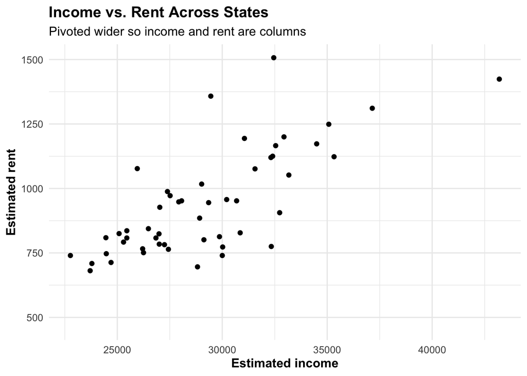

```r
library(tidyverse)

us_rent_income %>%
  pivot_wider(
    names_from  = variable,
    values_from = c(estimate, moe),
    names_sep   = "_"
  ) %>%
  ggplot(aes(x = estimate_income, y = estimate_rent)) +
  geom_point() +
  labs(
    title = "Income vs. Rent Across States",
    subtitle = "Pivoted wider so income and rent are columns",
    x = "Estimated income",
    y = "Estimated rent"
  ) +
  theme_minimal(base_size = 12) +
  theme(
    plot.title = element_text(face = "bold"),
    axis.title = element_text(face = "bold")
  )
```

# 6 one long tidyverse chain

```r
library(tidyverse)

nba  <- data.frame(
  player = c('A','A','B','B','C','C'),
  year   = c(1,2,1,2,1,2),
  stats  = c('22/2/3','29/3/4','18/6/7','11/1/2','12/1/1','19/2/4')
)
```

## 6.1 Separate stats into points, assists, steals → nba_sep

```r
nba_sep <- nba %>%
  separate(
    col =  stats,
    into = c("points", "assists", "steals"),
    sep = "/",
    convert = TRUE
  )

nba_sep
```

| player | year | points | assists | steals |
| --- | --- | --- | --- | --- |
| A | 1 | 22 | 2 | 3 |
| A | 2 | 29 | 3 | 4 |
| B | 1 | 18 | 6 | 7 |
| B | 2 | 11 | 1 | 2 |
| C | 1 | 12 | 1 | 1 |
| C | 2 | 19 | 2 | 4 |

## 6.2 Unite back into one column → mba_uni

```r
nba_uni <- nba_sep %>%
  unite(
    col = stats,
    points, assists, steals,
    sep = "/"
  )

nba_uni
```

| player | year | stats |
| --- | --- | --- |
| A | 1 | 22/2/3 |
| A | 2 | 29/3/4 |
| B | 1 | 18/6/7 |
| B | 2 | 11/1/2 |
| C | 1 | 12/1/1 |
| C | 2 | 19/2/4 |

# 7 flight departures

## 7.1 non-cancelled flights -> first/last depature each day

```r
library(tidyverse)
library(nycflights13)
library(gt)

# 1) first/last depature for non cancelled flights
daily_dep <- flights %>%
  filter(!is.na(dep_time)) %>%
  group_by(year, month, day) %>%
  summarise(
    first_dep = min(dep_time),
    last_dep = max(dep_time),
    n = n(),
    .groups = "drop"
  )

# 2) for each month, keep the day with the latest "first departure"\

latest_first_by_month <- daily_dep %>%
  group_by(year, month) %>%
  slice_max(first_dep, n = 1, with_ties = FALSE) %>%
  ungroup() %>%
  arrange(desc(first_dep))

# 3) GT table
latest_first_by_month %>%
  gt() %>%
  tab_header(
    title = "Latest First Departure Day (per Month)",
    subtitle = "Non-cancelled NYC flights; first_dep/last_dep are dep_time (HHMM)"
  ) %>%
  cols_label(
    year = "Year",
    month = "Month",
    day = "Day",
    first_dep = "First dep (HHMM)",
    last_dep = "Last dep (HHMM)",
    n = "Flights (n)"
  ) %>%
  fmt_number(columns = n, decimals = 0)
```

Latest First Departure Day (per Month)

Non-cancelled NYC flights; first_dep/last_dep are dep_time (HHMM)

| Year | Month | Day | First dep (HHMM) | Last dep (HHMM) | Flights (n) |
| --- | --- | --- | --- | --- | --- |
| 2013 | 2 | 9 | 901 | 2358 | 291 |
| 2013 | 1 | 20 | 525 | 2356 | 782 |
| 2013 | 9 | 29 | 521 | 2356 | 911 |
| 2013 | 10 | 6 | 519 | 2346 | 914 |
| 2013 | 11 | 3 | 519 | 2358 | 900 |
| 2013 | 3 | 3 | 509 | 2353 | 910 |
| 2013 | 12 | 18 | 500 | 2358 | 953 |
| 2013 | 5 | 29 | 457 | 2352 | 969 |
| 2013 | 6 | 15 | 456 | 2356 | 795 |
| 2013 | 4 | 30 | 455 | 2351 | 958 |
| 2013 | 8 | 31 | 455 | 2359 | 676 |
| 2013 | 7 | 5 | 38 | 2358 | 819 |

**Note**

dep_time is in HHMM “clock” format (e.g., 5 = 00:05, 2359 = 23:59). That’s why the table labels it HHMM.

## 7.2 flights in GT

```r
library(tidyverse)
library(nycflights13)
library(gt)

top5_dest_by_carrier <- flights %>%
  filter(!is.na(dep_time)) %>%
  count(carrier, dest, sort = TRUE) %>%
  group_by(carrier) %>%
  slice_max(n, n = 5, with_ties = FALSE) %>%
  ungroup() %>%
  arrange(carrier, desc(n))

top5_dest_by_carrier %>%
  gt(groupname_col = "carrier") %>%
  tab_header(
    title = "Top 5 Destinations by Carrier",
    subtitle = "Ranked by number of flights (NYC departures)"
  ) %>%
  cols_label(
    dest = "Destination",
    n = "Flights"
  ) %>%
  fmt_number(columns = n, decimals = 0)
```

Top 5 Destinations by Carrier

Ranked by number of flights (NYC departures)

| Destination | Flights |
| --- | --- |
| 9E |  |
| CVG | 1,473 |
| MSP | 1,208 |
| DCA | 1,016 |
| ORD | 989 |
| DTW | 958 |
| AA |  |
| MIA | 7,171 |
| DFW | 7,019 |
| ORD | 5,871 |
| LAX | 3,557 |
| BOS | 1,431 |
| AS |  |
| SEA | 712 |
| B6 |  |
| FLL | 6,486 |
| MCO | 6,415 |
| BOS | 4,328 |
| PBI | 3,129 |
| BUF | 2,774 |
| DL |  |
| ATL | 10,479 |
| DTW | 3,840 |
| MCO | 3,644 |
| MIA | 2,910 |
| FLL | 2,880 |
| EV |  |
| IAD | 3,829 |
| DTW | 2,401 |
| CLT | 2,382 |
| BNA | 2,063 |
| RIC | 2,027 |
| F9 |  |
| DEN | 682 |
| FL |  |
| ATL | 2,289 |
| CAK | 843 |
| MKE | 55 |
| HA |  |
| HNL | 342 |
| MQ |  |
| RDU | 4,554 |
| CMH | 2,550 |
| BNA | 2,313 |
| ATL | 2,248 |
| ORD | 2,108 |
| OO |  |
| CLE | 21 |
| MSP | 4 |
| DTW | 2 |
| IAD | 1 |
| ORD | 1 |
| UA |  |
| IAH | 6,831 |
| ORD | 6,773 |
| SFO | 6,762 |
| LAX | 5,783 |
| DEN | 3,757 |
| US |  |
| CLT | 8,508 |
| DCA | 4,487 |
| BOS | 4,012 |
| PHX | 2,242 |
| PHL | 624 |
| VX |  |
| LAX | 2,561 |
| SFO | 2,187 |
| LAS | 364 |
| PSP | 18 |
| SJC | 1 |
| WN |  |
| MDW | 4,044 |
| STL | 1,450 |
| DEN | 1,386 |
| HOU | 1,379 |
| MKE | 1,276 |
| YV |  |
| IAD | 279 |
| CLT | 258 |
| PHL | 8 |

# 8 Solar.R

## 8.1 how much is missing in Solar.R and at what percentage?

```r
library(tidyverse)
air.tib %>%
  summarise(
    n_rows = n(),
    n_missing_solar = sum(is.na(Solar.R)),
    pct_missing_solar = 100 * mean(is.na(Solar.R))
  )
```

| n_rows | n_missing_solar | pct_missing_solar |
| --- | --- | --- |
| 153 | 7 | 4.575163 |

## 8.2 find Solar.R mean, and replace missing Solar.R with it

```r
Solar_Mean <- air.tib %>%
  summarise(solar_mean = mean(Solar.R, na.rm = TRUE)) %>%
  pull(solar_mean)

Solar_Mean
```

```
[1] 185.9315
```

```r
air.tib <- air.tib %>%
  mutate(
    Solar.R = if_else(is.na(Solar.R), Solar_Mean, Solar.R)
  )
```

## 8.3 conformation of no missing Solar.R

```r
air.tib %>%
  summarise(n_missing_solar_after = sum(is.na(Solar.R)))
```

| n_missing_solar_after |
| --- |
| 0 |

# 9 monthly temprature

## 9.1 option 1

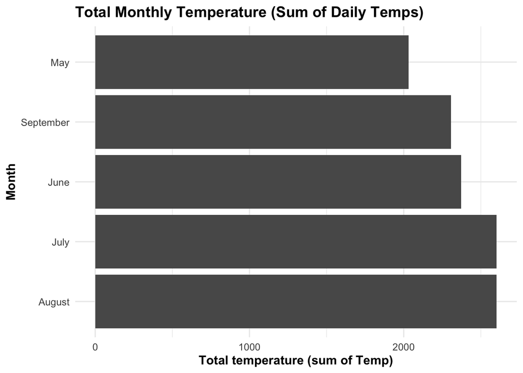

```r
library(tidyverse)

air.tib %>%
  group_by(Month) %>%
  summarise(n = sum(Temp, na.rm = TRUE), .groups = "drop") %>%   # total monthly Temp
  mutate(
    Month = recode(as.character(Month),
                   `5` = "May", `6` = "June", `7` = "July",
                   `8` = "August", `9` = "September"),
    Month = factor(Month),
    Month = fct_reorder(Month, n, .desc = TRUE)                  # reorder by total temp desc
  ) %>%
  ggplot(aes(x = n, y = Month)) +
  geom_col() +
  labs(
    title = "Total Monthly Temperature (Sum of Daily Temps)",
    x = "Total temperature (sum of Temp)",
    y = "Month"
  ) +
  theme_minimal(base_size = 12) +
  theme(
    plot.title = element_text(face = "bold"),
    axis.title = element_text(face = "bold")
  )
```

## 9.2 Option 2

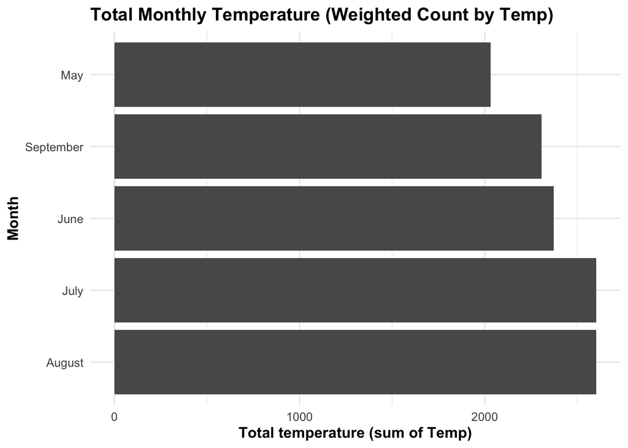

```r
library(tidyverse)

air.tib %>%
  count(Month, wt = Temp, name = "n") %>%                        # weighted count = sum(Temp)
  mutate(
    Month = recode(as.character(Month),
                   `5` = "May", `6` = "June", `7` = "July",
                   `8` = "August", `9` = "September"),
    Month = factor(Month),
    Month = fct_reorder(Month, n, .desc = TRUE)
  ) %>%
  ggplot(aes(x = n, y = Month)) +
  geom_col() +
  labs(
    title = "Total Monthly Temperature (Weighted Count by Temp)",
    x = "Total temperature (sum of Temp)",
    y = "Month"
  ) +
  theme_minimal(base_size = 12) +
  theme(
    plot.title = element_text(face = "bold"),
    axis.title = element_text(face = "bold")
  )
```

# 10 Ozone vs temprature

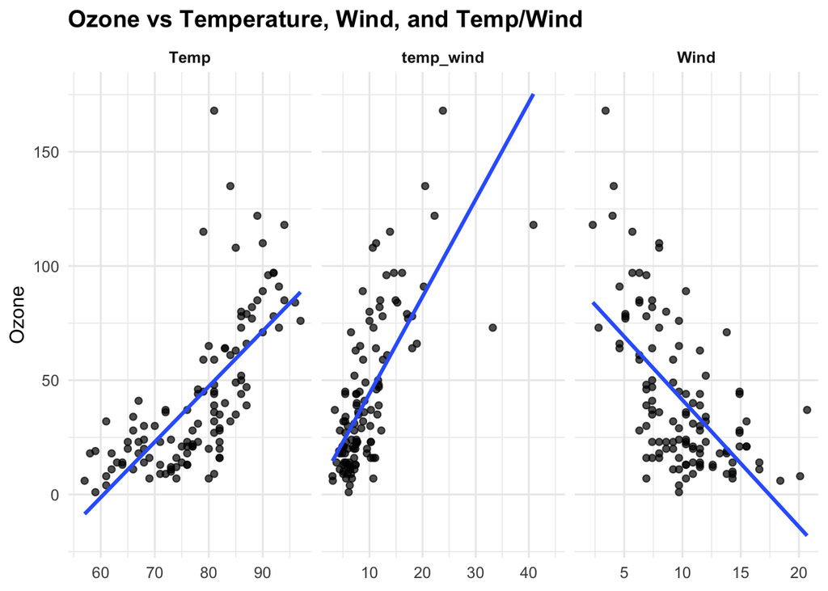

```r
library(tidyverse)

air.tib %>%
  mutate(temp_wind = Temp / Wind) %>%
  select(Ozone, Temp, Wind, temp_wind) %>%
  pivot_longer(
    cols = c(Temp, Wind, temp_wind),
    names_to = "predictor",
    values_to = "x"
  ) %>%
  ggplot(aes(x = x, y = Ozone)) +
  geom_point(alpha = 0.7, na.rm = TRUE) +
  geom_smooth(method = "lm", se = FALSE, na.rm = TRUE) +
  facet_wrap(~ predictor, scales = "free_x") +
  labs(
    title = "Ozone vs Temperature, Wind, and Temp/Wind",
    x = NULL,
    y = "Ozone"
  ) +
  theme_minimal(base_size = 12) +
  theme(
    plot.title = element_text(face = "bold"),
    strip.text = element_text(face = "bold")
  )
```

What can we gather from the data?

- there is a positive relationship between Ozone and Temprature
- opposite is true when we change temprature to wind
- Ozone vs wind temprature looks stronger since it is combining both affects
  - wind temprature increases when Temp is high and/or Wind is low, which are both conditions associated with higher ozone. So temp_wind acts like a simple “high-heat + low-wind” index, which tends to align more tightly with Ozone than either variable alone.